# Can We Predict Food Prices From Supply Chain, Economic, and Demographic Data in Developing Nations?

## By Sadia Nourin and Anna Feng

# 1. Introduction

In order to maintain economic stability in developing nations, central banks must set appropriate monetary policy, especially when it comes to inflation targeting. One of the variables central banks look at during the inflation targeting process is short-term food price forecasts. These food price forecasts could either be impacted by inflation or deflation, depending on the circumstances surrounding the developing nation (economic crises, supply chain bottlenecks, famine, refugee crisis, natural disasters or weather-related problems, etc.). However, it is of utmost importance that there be methods to accurately predict food prices even given such difficult-to-predict circumstances. This is to ensure that inflation, or deflation, does not spiral out of control in an already economically troubled nation.

Thus, the purpose of our project is to improve upon food price forecasts in developing nations in order to help central banks with their inflationary monetary policy decisions. We will load up various types of data that influence food prices (economic, supply chain, and demographic data), conduct a deep dive analysis of the data, and will end by creating and evaluating machine learning algorithms that will predict the food prices for these developing nations.

Some extra resources on this problem, and its many attempted solutions, are provided below. Not all of them are specific to inflation targeting, but they all deal with forecasting food prices for economic purposes and the many factors influencing food prices (you can access the articles that are behind paywalls through the university):

- Forecasting Food Inflation in Developing Countries with Inflation Targeting Regimes: https://www.jstor.org/stable/41331234?seq=1#metadata_info_tab_contents
- Forecasting food prices: The case of corn, soybeans and wheat: https://www.sciencedirect.com/science/article/abs/pii/S0169207016300073
- Global Food Projections to 2020: Implications for Investment: https://books.google.com/books?hl=en&lr=&id=XwQJorWEPT0C&oi=fnd&pg=PR4&dq=forecasting+food+prices+developing+countries
- Forecasting CPI Food Prices: An Assessment: https://www.jstor.org/stable/1244403?seq=1#metadata_info_tab_contents

**Note:** If running this notebook, please download the following files:

- Download the csv file from here: https://www.kaggle.com/lasaljaywardena/global-food-prices-dataset. Name this file "global_food_prices.csv" and place it within the csv_files directory in this repo.
- Download the csv file from here (click on "All Data" from the Bulk Downloads menu on the right hand side): https://www.fao.org/faostat/en/#data/FBSH. Name this file "food_balance_sheet_2013.csv" and place it within the csv_files directory as well.

Github will not allow us to upload files with sizes greater than 100 MB. Thus, we are not able to provide these files within our repo. We apologize for the inconvenience caused by this.

# 2. Data Curation, Parsing and Management

The goal of this data curation process is to combine a multitude of global food prices along with economic/supply chain data by country into one dataframe. Our primary dataset is the **global_food_prices.csv** but there are other factors such as gdp growth and inflation not captured that we want to include in our model. This requires us to merge separate csv files with that information into our primary dataset. Once that is complete, we drop any unnecessary columns, perform label mapping and entity resolution of our food items so everything is named the same, and clean up our data to fit in the range years 2000-2018. Finally, we perform mean imputation on some missing values in our dataset and ensure there are no nan values in the final dataframe.

We wanted to include more information related to circumstances developing in a country that may factor into price changes such as weather, famine, political upheaval, and more, but comprehensive datasets of these factors are difficult to find and often missing for countries. We included the supply chain information because like many bought/sold commodities, food prices are vulnerable to changes in the market and can be negatively effected by inflation/supply shortages/etc. We want to account for this relationship in our prediction model.

To begin, we have initial cleaning of our main dataset global_food_prices.csv.

```python
import pandas as pd
import numpy as np

#Loading in food price dataset
food_prices_df = pd.read_csv("csv_files/global_food_prices.csv")

#Removing unecessary columns
food_prices_df = food_prices_df.drop(["adm0_id", "adm1_id", "mkt_id", "cm_id",
                                      "cur_id", "pt_id", "um_id", "mp_commoditysource"], axis=1)

#Renaming columns to more appropriate names
food_prices_df = food_prices_df.rename({"adm0_name": "country", "adm1_name": "locality", "mkt_name": "market",
                                        "cm_name": "commodity", "cur_name" : "currency", "pt_name": "market_type",
                                        "um_name": "unit_of_measurement", "mp_month": "month", "mp_year": "year",
                                        "mp_price": "price"}, axis=1)

#Removing non-food commodities from dataframe
non_food_commodities = ["Wage (qualified labour) - Retail", "Fuel (diesel) - Retail", "Exchange rate - Retail",
                        "Wage (non-qualified labour, non-agricultural) - Retail", "Fuel (petrol-gasoline) - Retail",
                        "Fuel (kerosene) - Retail", "Wage (non-qualified labour) - Retail", "Fuel (gas) - Retail",
                        "Charcoal - Retail", "Laundry soap - Retail", "Laundry detergent - Retail",
                        "Fuel (diesel) - Wholesale", "Fuel (petrol-gasoline) - Wholesale", "Transport (public) - Retail",
                        "Transport (public, moto) - Retail", "Transport (public, bus) - Retail",
                        "Wage (casual labour) - Retail", "Exchange rate (unofficial) - Retail", "Fuel (Super Petrol) - Retail",
                        "Handwash soap - Retail", 'Firewood - Retail', 'Candles (small)  - Retail',
                        'Candles (big)  - Retail', 'Batteries (small) - Retail', 'Batteries (big) - Retail',
                        'Toothbrush - Retail', 'Sanitary pads - Retail', 'Toothpaste - Retail', 'Shampoo - Retail',
                        'Disinfecting solution - Retail', "Fuel (petrol-gasoline, 95 octane) - Retail",
                        "Wage (non-qualified labour, agricultural) - Retail", 'Diapers - Retail',
                        'Dishwashing liquid - Retail', 'Wage (non-qualified labour, livestock) - Retail',
                        'Feed (flour) - Retail', 'Feed (wheat bran) - Retail', 'Feed (rakhel) - Retail', 'Straw - Retail',
                        'Fuel (diesel, parallel market) - Retail', 'Fuel (petrol-gasoline, parallel market) - Retail',
                        'Milling cost (sorghum) - Retail', 'Milling cost (maize) - Retail', 'Fuel (gas, parallel market) - Retail',
                        'Multipurpose soap - Retail', 'Alcohol (spray) - Retail', 'Bleach (chlorine) - Retail',
                        'Surgical mask - Retail', 'Hand sanitizer (gel) - Retail', 'Plastic gloves - Retail',
                        'Internet bundle - Retail', 'Fuel (diesel, heating, parallel market) - Retail',
                        'Fuel (diesel, transport, parallel market) - Retail', 'Electricity - Retail',
                        'Milling cost (wheat) - Retail']


food_prices_df = food_prices_df[~(food_prices_df["commodity"].isin(non_food_commodities))]

#Averaging prices across months for the same year and aggregating based on locality and market
year_df_lst = []

food_prices_df = food_prices_df.groupby(["country", "commodity",
                                         "currency", "market_type", "unit_of_measurement",
                                         "year"]).mean()

food_prices_df = food_prices_df.drop(["month"], axis=1)
food_prices_df = food_prices_df.reset_index()


#Renaming Iran to be consistent
food_prices_df = food_prices_df.replace("Iran  (Islamic Republic of)", "Iran")

#Dropping current years, as our other datasets do not have data in these years
food_prices_df.drop(food_prices_df[food_prices_df["year"] == 2019].index, inplace = True)
food_prices_df.drop(food_prices_df[food_prices_df["year"] == 2020].index, inplace = True)
food_prices_df.drop(food_prices_df[food_prices_df["year"] == 2021].index, inplace = True)

food_prices_df
```

|  | country | commodity | currency | market_type | unit_of_measurement | year | price |
| --- | --- | --- | --- | --- | --- | --- | --- |
| 0 | Afghanistan | Bread - Retail | AFN | Retail | KG | 2000 | 17.213750 |
| 1 | Afghanistan | Bread - Retail | AFN | Retail | KG | 2001 | 16.522667 |
| 2 | Afghanistan | Bread - Retail | AFN | Retail | KG | 2002 | 11.587872 |
| 3 | Afghanistan | Bread - Retail | AFN | Retail | KG | 2003 | 13.016667 |
| 4 | Afghanistan | Bread - Retail | AFN | Retail | KG | 2004 | 15.622917 |
| ... | ... | ... | ... | ... | ... | ... | ... |
| 18120 | Zimbabwe | Wheat - Retail | USD | Retail | KG | 2015 | 0.485000 |
| 18121 | Zimbabwe | Wheat - Retail | USD | Retail | KG | 2016 | 0.500769 |
| 18122 | Zimbabwe | Wheat - Retail | USD | Retail | KG | 2017 | 0.550000 |
| 18123 | Zimbabwe | Wheat flour (fortified) - Retail | USD | Retail | KG | 2017 | 1.126316 |
| 18124 | Zimbabwe | Wheat flour (fortified) - Retail | USD | Retail | KG | 2018 | 1.322667 |

13123 rows × 7 columns

In the previous code block, we load up our primary dataset, the global food prices dataset for developing countries, separated primarily by commodity/food item and year. We found the dataset here: https://www.kaggle.com/lasaljaywardena/global-food-prices-dataset

We did some processing on the dataset to ensure the rows and columns were cohesive and meaningful. This included getting rid of ID columns and non-food commodities, renaming columns, aggregating the food prices by year, and standardizing country names (such as for Iran).

We noticed that this dataset didn't have many columns that a machine learning algorithm could use as its features, so we decided to add other datasets to this one, as described previously. Our other datasets had data available only until 2020 or 2018, so we dropped any rows from this dataset past 2018. Our process of merging the other datasets into this one is described below.

```python
#Loading gdp growth, inflation, unemployment rate, and population growth data from World Bank
food_prices_df["gdp_growth"] = np.nan
food_prices_df["inflation"] = np.nan
food_prices_df["unemployment_rate"] = np.nan
food_prices_df["population_growth"] = np.nan
food_prices_df["refugee_population"] = np.nan

gdp_growth_df = pd.read_csv("csv_files/gdp_growth.csv")
inflation_df = pd.read_csv("csv_files/inflation.csv")
unemployment_df = pd.read_csv("csv_files/unemployment.csv")
pop_growth_df = pd.read_csv("csv_files/population_growth.csv")
ref_pop_df = pd.read_csv("csv_files/refugee_population.csv")

#Renaming Iran to be consistent
gdp_growth_df = gdp_growth_df.replace("Iran, Islamic Rep.", "Iran")
inflation_df = inflation_df.replace("Iran, Islamic Rep.", "Iran")
unemployment_df = unemployment_df.replace("Iran, Islamic Rep.", "Iran")
pop_growth_df = pop_growth_df.replace("Iran, Islamic Rep.", "Iran")
ref_pop_df = ref_pop_df.replace("Iran, Islamic Rep.", "Iran")

group_df_lst = []

#Merging gdp growth, inflation, unemployment rate, and population growth data into our
#global food prices dataset
country_year_groups = food_prices_df.groupby(["country", "year"])
for group_name in country_year_groups.groups.keys():
    group_df = country_year_groups.get_group(group_name)

    if group_name[1] != 2021:
        gdp_growth_val = gdp_growth_df[gdp_growth_df["Country Name"] == group_name[0]][str(group_name[1])]
        inflation_val = inflation_df[inflation_df["Country Name"] == group_name[0]][str(group_name[1])]
        unemployment_val = unemployment_df[unemployment_df["Country Name"] == group_name[0]][str(group_name[1])]
        pop_growth_val = pop_growth_df[pop_growth_df["Country Name"] == group_name[0]][str(group_name[1])]
        ref_pop_val = ref_pop_df[ref_pop_df["Country Name"] == group_name[0]][str(group_name[1])]

        if gdp_growth_val.empty:
            gdp_growth_val = np.nan
        else:
            gdp_growth_val = gdp_growth_val.iloc[0]

        if inflation_val.empty:
            inflation_val = np.nan
        else:
            inflation_val = inflation_val.iloc[0]

        if unemployment_val.empty:
            unemployment_val = np.nan
        else:
            unemployment_val = unemployment_val.iloc[0]

        if pop_growth_val.empty:
            pop_growth_val = np.nan
        else:
            pop_growth_val = pop_growth_val.iloc[0]

        if ref_pop_val.empty:
            ref_pop_val = np.nan
        else:
            ref_pop_val = ref_pop_val.iloc[0]

        group_df = group_df.copy()
        group_df["gdp_growth"].replace({np.nan: gdp_growth_val}, inplace=True)
        group_df["inflation"].replace({np.nan: inflation_val}, inplace=True)
        group_df["unemployment_rate"].replace({np.nan: unemployment_val}, inplace=True)
        group_df["population_growth"].replace({np.nan: pop_growth_val}, inplace=True)
        group_df["refugee_population"].replace({np.nan: ref_pop_val}, inplace=True)

    group_df_lst.append(group_df)


food_prices_df = pd.DataFrame()

for df in group_df_lst:
    food_prices_df = pd.concat([food_prices_df, df])

food_prices_df = food_prices_df.reset_index()
food_prices_df
```

|  | index | country | commodity | currency | market_type | unit_of_measurement | year | price | gdp_growth | inflation | unemployment_rate | population_growth | refugee_population |
| --- | --- | --- | --- | --- | --- | --- | --- | --- | --- | --- | --- | --- | --- |
| 0 | 0 | Afghanistan | Bread - Retail | AFN | Retail | KG | 2000 | 1.721375e+01 | NaN | NaN | 11.65 | 2.975057 | 3587327.0 |
| 1 | 22 | Afghanistan | Livestock (sheep, one-year-old alive female) -... | AFN | Retail | Unit | 2000 | 1.060087e+06 | NaN | NaN | 11.65 | 2.975057 | 3587327.0 |
| 2 | 50 | Afghanistan | Wheat - Retail | AFN | Retail | KG | 2000 | 1.211646e+01 | NaN | NaN | 11.65 | 2.975057 | 3587327.0 |
| 3 | 76 | Afghanistan | Wheat flour - Retail | AFN | Retail | KG | 2000 | 1.420292e+01 | NaN | NaN | 11.65 | 2.975057 | 3587327.0 |
| 4 | 1 | Afghanistan | Bread - Retail | AFN | Retail | KG | 2001 | 1.652267e+01 | NaN | NaN | 11.63 | 3.902805 | 3809763.0 |
| ... | ... | ... | ... | ... | ... | ... | ... | ... | ... | ... | ... | ... | ... |
| 13118 | 18101 | Zimbabwe | Oil (vegetable, fortified) - Retail | USD | Retail | L | 2018 | 2.167952e+00 | 2.0477 | 61.310986 | 5.07 | 1.410382 | 15618.0 |
| 13119 | 18107 | Zimbabwe | Sorghum (biofortified) - Retail | USD | Retail | KG | 2018 | 1.000000e+00 | 2.0477 | 61.310986 | 5.07 | 1.410382 | 15618.0 |
| 13120 | 18112 | Zimbabwe | Sorghum - Retail | USD | Retail | KG | 2018 | 4.152941e-01 | 2.0477 | 61.310986 | 5.07 | 1.410382 | 15618.0 |
| 13121 | 18116 | Zimbabwe | Sugar (white, fortified) - Retail | USD | Retail | KG | 2018 | 1.291429e+00 | 2.0477 | 61.310986 | 5.07 | 1.410382 | 15618.0 |
| 13122 | 18124 | Zimbabwe | Wheat flour (fortified) - Retail | USD | Retail | KG | 2018 | 1.322667e+00 | 2.0477 | 61.310986 | 5.07 | 1.410382 | 15618.0 |

13123 rows × 13 columns

We wanted to have economic and demographic data along with our global food prices data, so we obtained this data from the following sources:

- GDP Growth: https://data.worldbank.org/indicator/NY.GDP.PCAP.KD.ZG?end=2020&start=1960&view=chart
- Inflation: https://data.worldbank.org/indicator/NY.GDP.DEFL.KD.ZG?end=2020&start=1960&view=map
- Unemployment: https://data.worldbank.org/indicator/SL.UEM.TOTL.ZS?view=chart
- Population Growth: https://data.worldbank.org/indicator/SP.POP.GROW?view=chart
- Refugee Population By Country of Origin: https://data.worldbank.org/indicator/SM.POP.REFG.OR?view=chart

Since the data came from the same organization, the World Bank, it was convinient to use the same process for each dataset. We created dummy columns to hold the data in the food prices dataframe, loaded up the datasets, renamed countries for consistency, and merged the data into our food prices dataframe by grouping the food prices dataframe by country and year, and matching each group with the values from these datasets (also retrieved given country and year).

```python
#Loading in food balance sheet dataset
food_balance_sheet_2013_df = pd.read_csv("csv_files/food_balance_sheet_2013.csv", encoding = "ISO-8859-1")
food_balance_sheet_2018_df = pd.read_csv("csv_files/food_balance_sheet_2018.csv", encoding = "ISO-8859-1")
food_balance_sheet_df = pd.merge(food_balance_sheet_2013_df, food_balance_sheet_2018_df,
                                 on=["Area", "Item", "Element", "Area Code", "Item Code", "Element Code", "Unit"])

#Removing unecessary columns
drop_lst = []
for i in range(1961, 2019):
    if i < 2000:
        drop_lst.append("Y" + str(i))
        drop_lst.append("Y" + str(i) + "F")
    else:
        drop_lst.append("Y" + str(i) + "F")


drop_lst = drop_lst + ["Area Code", "Item Code", "Element Code"]
food_balance_sheet_df = food_balance_sheet_df.drop(drop_lst, axis=1)

rename_dict = {}
for i in range(2000, 2019):
    rename_dict["Y" + str(i)] = str(i)

#Renaming columns to more appropriate names
food_balance_sheet_df = food_balance_sheet_df.rename(rename_dict, axis=1)

#Removing extra countries
country_lst = list(food_prices_df["country"].unique())
food_balance_sheet_df.drop(food_balance_sheet_df[~(food_balance_sheet_df["Area"].isin(country_lst))].index, inplace = True)

#Removing extra elements
column_lst = list(food_balance_sheet_df["Element"].unique())
column_lst.remove("Other uses (non-food)")
column_lst.remove("Food supply quantity (kg/capita/yr)")
column_lst.remove("Food supply (kcal/capita/day)")
column_lst.remove("Protein supply quantity (g/capita/day)")
column_lst.remove("Fat supply quantity (g/capita/day)")
column_lst

food_balance_sheet_df = food_balance_sheet_df[food_balance_sheet_df['Element'].isin(column_lst)]

food_balance_sheet_df
```

|  | Area | Item | Element | Unit | 2000 | 2001 | 2002 | 2003 | 2004 | 2005 | ... | 2009 | 2010 | 2011 | 2012 | 2013 | 2014 | 2015 | 2016 | 2017 | 2018 |
| --- | --- | --- | --- | --- | --- | --- | --- | --- | --- | --- | --- | --- | --- | --- | --- | --- | --- | --- | --- | --- | --- |
| 0 | Afghanistan | Population | Total Population - Both sexes | 1000 persons | 20595.0 | 21348.0 | 22203.0 | 23116.0 | 24019.0 | 24861.0 | ... | 27708.0 | 28398.0 | 29105.0 | 29825.0 | 30552.0 | 33371.0 | 34414.0 | 35383.0 | 36296.0 | 37172.0 |
| 10 | Afghanistan | Cereals - Excluding Beer | Production | 1000 tonnes | 1853.0 | 2027.0 | 3608.0 | 4236.0 | 3406.0 | 5263.0 | ... | 6299.0 | 5733.0 | 4457.0 | 6213.0 | 6350.0 | 6748.0 | 5816.0 | 5537.0 | 4900.0 | 4141.0 |
| 11 | Afghanistan | Cereals - Excluding Beer | Import Quantity | 1000 tonnes | 1154.0 | 1509.0 | 1277.0 | 936.0 | 749.0 | 1176.0 | ... | 1921.0 | 1307.0 | 1868.0 | 1482.0 | 1303.0 | 1692.0 | 2039.0 | 3056.0 | 3630.0 | 3882.0 |
| 12 | Afghanistan | Cereals - Excluding Beer | Stock Variation | 1000 tonnes | 550.0 | 200.0 | -600.0 | -300.0 | 800.0 | -850.0 | ... | -1300.0 | -200.0 | 400.0 | -500.0 | -350.0 | 233.0 | -89.0 | 60.0 | 155.0 | 141.0 |
| 13 | Afghanistan | Cereals - Excluding Beer | Export Quantity | 1000 tonnes | 0.0 | 0.0 | 0.0 | 0.0 | 0.0 | 0.0 | ... | 0.0 | 0.0 | 0.0 | 0.0 | 0.0 | 2.0 | 1.0 | 0.0 | 2.0 | 2.0 |
| ... | ... | ... | ... | ... | ... | ... | ... | ... | ... | ... | ... | ... | ... | ... | ... | ... | ... | ... | ... | ... | ... |
| 171498 | Zimbabwe | Miscellaneous | Food | 1000 tonnes | 0.0 | 0.0 | 0.0 | 0.0 | 0.0 | 0.0 | ... | 0.0 | 0.0 | 0.0 | 0.0 | 0.0 | 42.0 | 46.0 | 33.0 | 19.0 | 16.0 |
| 171503 | Zimbabwe | Infant food | Import Quantity | 1000 tonnes | 0.0 | 0.0 | 0.0 | 0.0 | 0.0 | 0.0 | ... | 0.0 | 0.0 | 0.0 | 0.0 | 0.0 | 0.0 | 0.0 | 0.0 | 0.0 | 0.0 |
| 171504 | Zimbabwe | Infant food | Export Quantity | 1000 tonnes | 0.0 | 0.0 | 0.0 | 0.0 | 0.0 | 0.0 | ... | 0.0 | 0.0 | 0.0 | 0.0 | 0.0 | 0.0 | 0.0 | 0.0 | 0.0 | 0.0 |
| 171505 | Zimbabwe | Infant food | Domestic supply quantity | 1000 tonnes | 0.0 | 0.0 | 0.0 | 0.0 | 0.0 | 0.0 | ... | 0.0 | 0.0 | 0.0 | 0.0 | 0.0 | 0.0 | 0.0 | 0.0 | 0.0 | 0.0 |
| 171506 | Zimbabwe | Infant food | Food | 1000 tonnes | 0.0 | 0.0 | 0.0 | 0.0 | 0.0 | 0.0 | ... | 0.0 | 0.0 | 0.0 | 0.0 | 0.0 | 0.0 | 0.0 | 0.0 | 0.0 | 0.0 |

46664 rows × 23 columns

In the previous code block, we load up the supply chain dataset that we will be adding to the food prices dataset. The datasets we used to create the food supply chain dataset are taken from the sources below:

- Food Balances 1961-2013: https://www.fao.org/faostat/en/#data/FBSH
- Food Balances 2014-2018: https://www.fao.org/faostat/en/#data/FBS

The food balances/supply chain datasets are only available up until 2018. On the other hand, our global food prices dataset only go back until 1991. Ideally, we would like to focus our algorithms on more recent data. Thus, we decided to only focus on the years 2000-2018 (the years leading up to the Global Recession of 2007-2009 and the recovery years afterwards, leading up to the most recent data we have available).

For processing the food balances/supply chain dataset, we load up the dataset, remove any exra columns and any years before 2000, rename the columns to have cohesive and consistent names, and then remove any attributes we don't need from the dataset, such as non-food uses of the commodities and supply quantity broken down by macronutrients.

```python
#Creating a base for each commodity in the food prices dataframe
def commodity_stripper(c):
    if "(" in c:
        c = c.split("(")[0].strip()
    else:
        c = c.split(" -")[0].strip()

    return c

food_prices_df["commodity_base"] = [commodity_stripper(x) for x in food_prices_df["commodity"]]

#Mapping commodities from food_prices_df to food_balance_sheet_df
food_mapper = {}
food_mapper['Bread'] = "Wheat and products"
food_mapper['Livestock'] = "Meat"
food_mapper['Wheat'] = "Wheat and products"
food_mapper['Wheat flour'] = "Wheat and products"
food_mapper['Rice'] = "Cereals - Excluding Beer"
food_mapper['Apples'] = "Apples and products"
food_mapper['Bananas'] = "Bananas"
food_mapper['Beans'] = "Beans"
food_mapper['Carrots'] = "Starchy Roots"
food_mapper['Cheese'] = "Milk - Excluding Butter"
food_mapper['Eggs'] = "Eggs"
food_mapper['Fish'] = "Fish, Seafood"
food_mapper['Lentils'] = "Pulses"
food_mapper['Meat'] = "Meat"
food_mapper['Milk'] = "Milk - Excluding Butter"
food_mapper['Oil'] = "Vegetable Oils"
food_mapper['Onions'] = "Onions"
food_mapper['Oranges'] = "Oranges, Mandarines"
food_mapper['Pasta'] = "Wheat and products"
food_mapper['Potatoes'] = "Potatoes and products"
food_mapper['Sugar'] = "Sugar (Raw Equivalent)"
food_mapper['Tea'] = "Tea (including mate)"
food_mapper['Tomatoes'] = "Tomatoes and products"
food_mapper['Cassava flour'] = "Cassava and products"
food_mapper['Maize flour'] = "Maize and products"
food_mapper['Maize meal'] = "Maize and products"
food_mapper['Salt'] = "Spices, Other"
food_mapper['Maize'] = "Maize and products"
food_mapper['Cabbage'] = "Vegetables"
food_mapper['Cucumbers'] = "Vegetables"
food_mapper['Beetroots'] = "Roots, Other"
food_mapper['Buckwheat'] = "Cereals, Other"
food_mapper['Peas'] = "Peas"
food_mapper['Chickpeas'] = "Pulses"
food_mapper['Ghee'] = "Butter, Ghee"
food_mapper['Millet'] = "Millet and products"
food_mapper['Sorghum'] = "Sorghum and products"
food_mapper['Cassava meal'] = "Cassava and products"
food_mapper['Yam'] = "Yams"
food_mapper['Noodles'] = "Wheat and products"
food_mapper['Quinoa'] = "Cereals, Other"
food_mapper['Groundnuts'] = "Nuts and products"
food_mapper['Sweet potatoes'] = "Sweet potatoes"
food_mapper['Avocados'] = "Fruits - Excluding Wine"
food_mapper['Prawn'] = "Crustaceans"
food_mapper['Soybeans'] = "Soyabeans"
food_mapper['Cassava'] = "Cassava and products"
food_mapper['Plantains'] = "Plantains"
food_mapper['Taro'] = "Starchy Roots"
food_mapper['Sesame'] = "Sesame seed"
food_mapper['Cocoyam'] = "Starchy Roots"
food_mapper['Cowpeas'] = "Pulses"
food_mapper['Chicken'] = "Poultry Meat"
food_mapper['Squashes'] = "Vegetables"
food_mapper['Coffee'] = "Coffee and products"
food_mapper['Cauliflower'] = "Vegetables"
food_mapper['Cocoa'] = "Cocoa Beans and products"
food_mapper['Garlic'] = "Vegetables"
food_mapper['Blackberry'] = "Fruits - Excluding Wine"
food_mapper['Broccoli'] = "Vegetables"
food_mapper['Guava'] = "Fruits - Excluding Wine"
food_mapper['Mangoes'] = "Fruits - Excluding Wine"
food_mapper['Papaya'] = "Fruits - Excluding Wine"
food_mapper['Pumpkin'] = "Vegetables"
food_mapper['Spinach'] = "Vegetables"
food_mapper['Cashew nut'] = "Treenuts"
food_mapper['Cornstarch'] = "Maize and products"
food_mapper['Peanut'] = "Nuts and products"
food_mapper['Cotton'] = "Cottonseed"
food_mapper['Barley'] = "Barley and products"
food_mapper['Teff'] = "Cereals - Excluding Beer"
food_mapper['Corn Soy Blend'] = "Maize and products"
food_mapper['Fonio'] = "Cereals - Excluding Beer"
food_mapper['Tortilla'] = "Wheat and products"
food_mapper['Chili'] = "Pepper"
food_mapper['Dates'] = "Dates"
food_mapper['Radish'] = "Roots, Other"
food_mapper['Pulses'] = "Pulses"
food_mapper['Bulgur'] = "Wheat and products"
food_mapper['Buckwheat grits'] = "Cereals, Other"
food_mapper['Butter'] = "Butter, Ghee"
food_mapper['Kefir'] = "Beverages, Fermented"
food_mapper['Semolina'] = "Wheat and products"
food_mapper['Walnuts'] = "Treenuts"
food_mapper['Lettuce'] = "Vegetables"
food_mapper['Wheat meal'] = "Wheat and products"
food_mapper['Bitterball'] = "Vegetables"
food_mapper['Cane juice'] = "Sugar cane"
food_mapper['Peppers'] = "Pepper"
food_mapper['Couscous'] = "Wheat and products"
food_mapper['Water'] = "Miscellaneous"
food_mapper['Pigeon peas'] = "Pulses"
food_mapper['Gari'] = "Cassava and products"
food_mapper['Watermelons'] = "Fruits - Excluding Wine"
food_mapper['Poultry'] = "Poultry Meat"
food_mapper['Eggplants'] = "Vegetables"
food_mapper['Passion fruit'] = "Fruits - Excluding Wine"
food_mapper['Sorghum flour'] = "Sorghum and products"
food_mapper['Zucchini'] = "Vegetables"
food_mapper['Cassava leaves'] = "Cassava and products"
food_mapper['Labaneh'] = "Milk - Excluding Butter"
food_mapper['Yogurt'] = "Milk - Excluding Butter"
food_mapper['Parsley'] = "Vegetables"
food_mapper['Yeast'] = "Miscellaneous"
food_mapper['Curd'] = "Milk - Excluding Butter"
food_mapper['Fat'] = "Animal fats"
food_mapper['Sour cream'] = "Cream"

food_prices_df["commodity_mapping"] = [food_mapper[x] for x in food_prices_df["commodity_base"]]

#Removing any commodities from the food_balance_sheet_df that is not in the food_mapper
#This is done to make food_balance_sheet_df more manageable
food_mapper_vals = list(food_mapper.values())
food_balance_sheet_df = food_balance_sheet_df[food_balance_sheet_df['Item'].isin(food_mapper_vals)]

#Creating a string list of all the years we would like to
#focus on
year_lst = []
for i in range(2000, 2019):
    year_lst.append(str(i))

#The food_balance_sheet_df is in a melted form, so we must unmelt the dataframe and then do an
#inner join on the food_prices_df (based on country, year, and the commodity_base) in order
#to combine the dataframes together
food_balance_sheet_df = pd.melt(food_balance_sheet_df, id_vars=["Area", "Item", "Unit", "Element"],
                                value_vars=year_lst,
                                var_name="year", value_name="value")
food_balance_sheet_df = pd.pivot_table(food_balance_sheet_df, index=["Area", "Item", "Unit", "year"],
                                       columns=["Element"], values=["value"])

food_balance_sheet_df.columns = food_balance_sheet_df.columns.droplevel()
food_balance_sheet_df = food_balance_sheet_df.rename_axis(None,axis=1).reset_index()
food_balance_sheet_df = food_balance_sheet_df.rename({"Area": "country", "Item": "commodity_mapping"}, axis=1)

food_prices_df['year']=food_prices_df['year'].astype(str)

food_prices_df = food_prices_df.merge(food_balance_sheet_df, how="inner", on=["country", "year", "commodity_mapping"])
food_prices_df
```

|  | index | country | commodity | currency | market_type | unit_of_measurement | year | price | gdp_growth | inflation | ... | Domestic supply quantity | Export Quantity | Feed | Food | Import Quantity | Losses | Processing | Production | Seed | Stock Variation |
| --- | --- | --- | --- | --- | --- | --- | --- | --- | --- | --- | --- | --- | --- | --- | --- | --- | --- | --- | --- | --- | --- |
| 0 | 0 | Afghanistan | Bread - Retail | AFN | Retail | KG | 2000 | 1.721375e+01 | NaN | NaN | ... | 2898.0 | NaN | NaN | 2600.0 | 929.0 | 147.0 | NaN | 1469.0 | 151.0 | 500.0 |
| 1 | 50 | Afghanistan | Wheat - Retail | AFN | Retail | KG | 2000 | 1.211646e+01 | NaN | NaN | ... | 2898.0 | NaN | NaN | 2600.0 | 929.0 | 147.0 | NaN | 1469.0 | 151.0 | 500.0 |
| 2 | 76 | Afghanistan | Wheat flour - Retail | AFN | Retail | KG | 2000 | 1.420292e+01 | NaN | NaN | ... | 2898.0 | NaN | NaN | 2600.0 | 929.0 | 147.0 | NaN | 1469.0 | 151.0 | 500.0 |
| 3 | 22 | Afghanistan | Livestock (sheep, one-year-old alive female) -... | AFN | Retail | Unit | 2000 | 1.060087e+06 | NaN | NaN | ... | 319.0 | NaN | NaN | 319.0 | 0.0 | NaN | NaN | 319.0 | NaN | NaN |
| 4 | 1 | Afghanistan | Bread - Retail | AFN | Retail | KG | 2001 | 1.652267e+01 | NaN | NaN | ... | 2976.0 | NaN | NaN | 2668.0 | 1229.0 | 160.0 | NaN | 1597.0 | 148.0 | 150.0 |
| ... | ... | ... | ... | ... | ... | ... | ... | ... | ... | ... | ... | ... | ... | ... | ... | ... | ... | ... | ... | ... | ... |
| 10687 | 18101 | Zimbabwe | Oil (vegetable, fortified) - Retail | USD | Retail | L | 2018 | 2.167952e+00 | 2.0477 | 61.310986 | ... | 199.0 | 1.0 | NaN | 160.0 | 140.0 | NaN | 31.0 | 92.0 | NaN | 32.0 |
| 10688 | 18107 | Zimbabwe | Sorghum (biofortified) - Retail | USD | Retail | KG | 2018 | 1.000000e+00 | 2.0477 | 61.310986 | ... | 103.0 | 5.0 | 2.0 | 68.0 | 8.0 | 3.0 | 26.0 | 100.0 | 5.0 | 0.0 |
| 10689 | 18112 | Zimbabwe | Sorghum - Retail | USD | Retail | KG | 2018 | 4.152941e-01 | 2.0477 | 61.310986 | ... | 103.0 | 5.0 | 2.0 | 68.0 | 8.0 | 3.0 | 26.0 | 100.0 | 5.0 | 0.0 |
| 10690 | 18116 | Zimbabwe | Sugar (white, fortified) - Retail | USD | Retail | KG | 2018 | 1.291429e+00 | 2.0477 | 61.310986 | ... | 350.0 | 85.0 | NaN | 299.0 | 0.0 | NaN | 51.0 | 435.0 | NaN | 0.0 |
| 10691 | 18124 | Zimbabwe | Wheat flour (fortified) - Retail | USD | Retail | KG | 2018 | 1.322667e+00 | 2.0477 | 61.310986 | ... | 301.0 | 3.0 | NaN | 298.0 | 310.0 | 1.0 | 1.0 | 45.0 | 2.0 | 50.0 |

10692 rows × 26 columns

The previous code block is quite extensive, but we are doing a simply task: merging the food supply dataset and the food prices dataset. We first create a new column in the food prices dataset, which holds the base of whatever food/commodity is in the commodity column. By base, we mean that we remove any information on the type (retail, wholesale), agricultural process, etc. For example, if the food string was "Sorghum - Retail" then our base is "Sorghum".

We then conduct entity resolution between the food prices and food balance/supply chain data by creating a mapping between the commodity base and the food groups that the food balance/supply chain data holds. This has to be done manually because there are too many food items that do not have a one-to-one matching with a food group.

Next, we get rid of any items in the food balance/supply chain data that is not within the food mapper, so that we have a smaller and more manageable dataframe to deal with.

```python
#Checking to see how many missing values we have
food_prices_df.isnull().sum()
```

```
index                          0
country                        0
commodity                      0
currency                       0
market_type                    0
unit_of_measurement            0
year                           0
price                          0
gdp_growth                  1342
inflation                   1342
unemployment_rate           1268
population_growth           1268
refugee_population          1268
commodity_base                 0
commodity_mapping              0
Unit                           0
Domestic supply quantity       0
Export Quantity              992
Feed                        5226
Food                           7
Import Quantity              374
Losses                      2514
Processing                  6499
Production                   624
Seed                        4232
Stock Variation             1709
dtype: int64
```

In the previous code block, we simply check what missing values we have, so we can figure out how to fill them in, or drop them.

```python
#Dropping columns because they have too many missing values
food_prices_df = food_prices_df.drop(["Processing", "Seed"], axis=1)

#Missing Value Imputation
missing_val_columns = ["gdp_growth", "inflation", "unemployment_rate", "population_growth", "refugee_population",
                       "Export Quantity", "Feed", "Food", "Import Quantity", "Losses", "Production", "Stock Variation"]

food_prices_df = food_prices_df.set_index(['country'])

for col in missing_val_columns:
    mean_imputation_values = food_prices_df.groupby(["country"])[col].mean()
    food_prices_df[col] = food_prices_df[col].fillna(mean_imputation_values)

food_prices_df = food_prices_df.reset_index()

#For countries that have the entire column missing, just use mean of all data in that column
missing_val_columns = ["gdp_growth", "inflation", "unemployment_rate", "population_growth", "refugee_population",
                       "Feed"]

for col in missing_val_columns:
    food_prices_df[col].fillna(food_prices_df[col].mean(), inplace=True)

food_prices_df.isnull().sum()
```

```
country                     0
index                       0
commodity                   0
currency                    0
market_type                 0
unit_of_measurement         0
year                        0
price                       0
gdp_growth                  0
inflation                   0
unemployment_rate           0
population_growth           0
refugee_population          0
commodity_base              0
commodity_mapping           0
Unit                        0
Domestic supply quantity    0
Export Quantity             0
Feed                        0
Food                        0
Import Quantity             0
Losses                      0
Production                  0
Stock Variation             0
dtype: int64
```

In the previous code block, we get rid of the "Processing" and "Seed" columns, because they have a large amount of missing values, and its just not reasonable to impute missing values for them.

For the rest of the columns, we impute the missing values by taking the mean of the columns by country. If there are still any missing values left after this step (which is possible because the entire country's values could be missing for a specific column), we just impute the missing values via the mean of the entire column. We then check to ensure we have no more missing values.

# 3. Exploratory Data Analysis

The goal of our EDA is to take a look at any existing relationships between our food prices and other factors we want to include in our predication model. We want our model to work universally with each country. Understanding any trends among our factors can help us contextualize our data and discover any caveats we might want to know as we develop our model. In summary, our EDA will explore food price trends at a global scale, then on the basis of an individual country, and correlations among factors on food prices.

To get started we will graph the price of food items over time to see if there is a relationship of them rising and falling. We will capture the rise and fall of global prices by averaging prices of items across our countries.

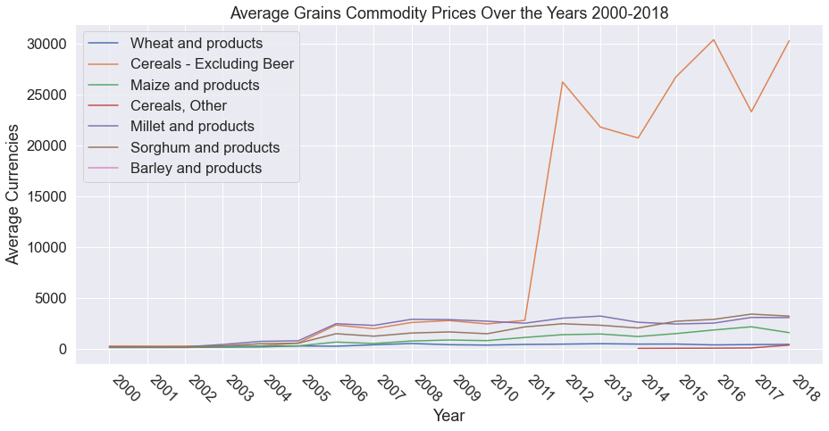

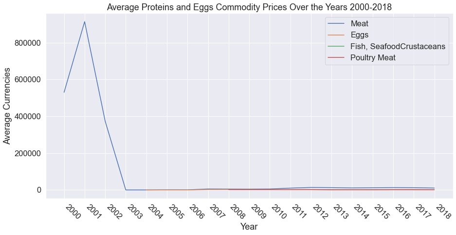

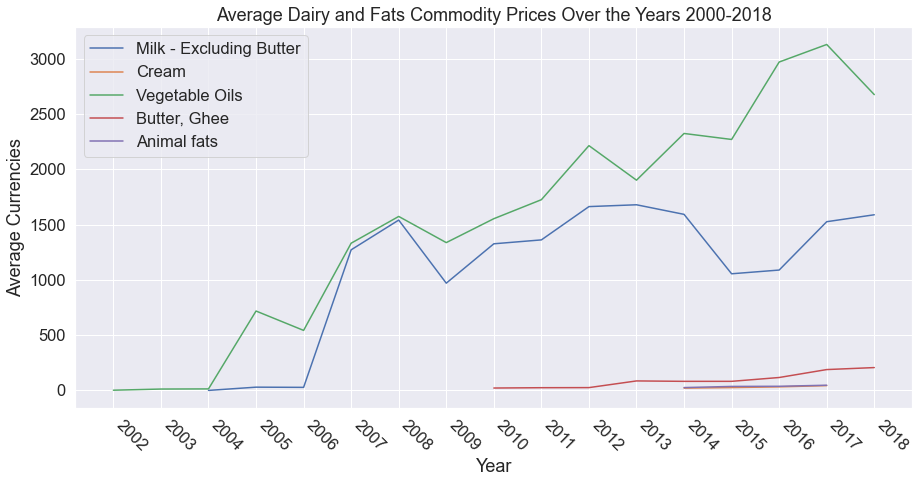

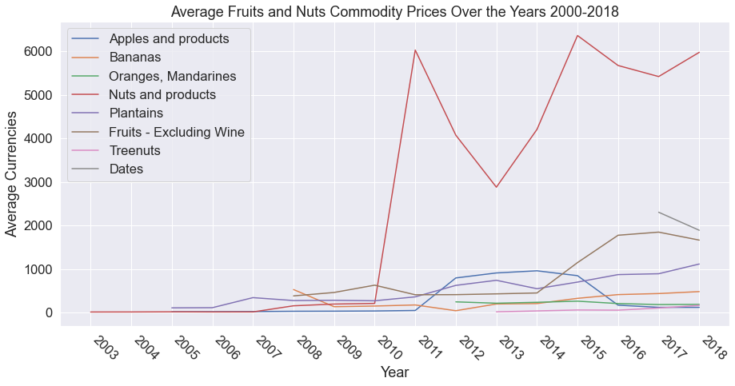

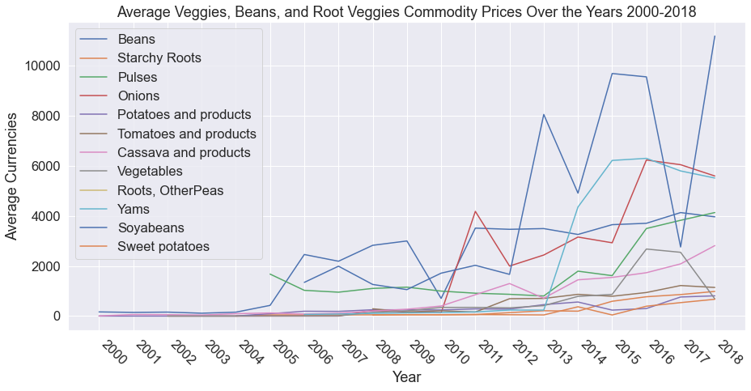

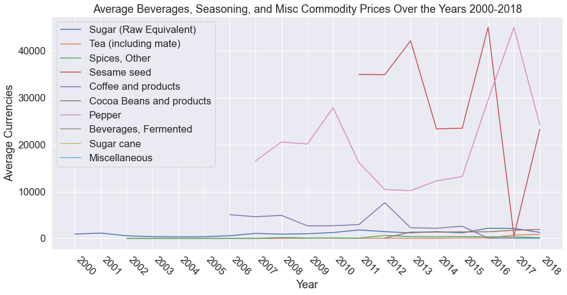

```python
import seaborn as sns
import matplotlib.pyplot as plt

sns.set(rc={"figure.figsize":(15, 7)}, font_scale = 1.5)

# Year labels
years = food_prices_df["year"].unique()

# Food groups to organize our food items to graphs
grains = ['Wheat and products', 'Cereals - Excluding Beer', 'Maize and products', 'Cereals, Other', 'Millet and products', 'Sorghum and products', \
    'Barley and products']
proteins = ['Meat', 'Eggs', 'Fish, Seafood''Crustaceans', 'Poultry Meat']
dairy_fats= ['Milk - Excluding Butter', 'Cream', 'Vegetable Oils', 'Butter, Ghee', 'Animal fats']
fruits_nuts = [ 'Apples and products', 'Bananas', 'Oranges, Mandarines', 'Nuts and products', 'Plantains', 'Fruits - Excluding Wine' , \
                'Treenuts', 'Dates']
veggies_roots = ['Beans', 'Starchy Roots','Pulses', 'Onions', 'Potatoes and products', 'Tomatoes and products', 'Cassava and products', 'Vegetables', \
                'Roots, Other' 'Peas', 'Yams', 'Soyabeans', 'Sweet potatoes'  ]
beverages_misc = ['Sugar (Raw Equivalent)', 'Tea (including mate)', 'Spices, Other' , 'Sesame seed', 'Coffee and products', 'Cocoa Beans and products', \
    'Pepper', 'Beverages, Fermented', 'Sugar cane', 'Miscellaneous']

# Labels for our groups
commodity_names = ['Grains', 'Proteins and Eggs', 'Dairy and Fats', 'Fruits and Nuts', 'Veggies, Beans, and Root Veggies', 'Beverages, Seasoning, and Misc']
# Putting our grouped names into one list, for iterating over
commodities = [grains, proteins, dairy_fats, fruits_nuts, veggies_roots, beverages_misc]
# index for our labels
name_index = 0;
# repeat graphing process over our commodities
for group in commodities:
    plt.figure()
    plt.xticks(rotation = -45, horizontalalignment='left')
    plt.title("Average " + commodity_names[name_index] + " Commodity Prices Over the Years 2000-2018")
    plt.xlabel("Year")
    plt.ylabel("Average Currencies")
    # for each food item in the group we will find their average prices over years
    for item in group:
        mean_prices = []
        # for each year find the mean
        for year in years:
            mean_prices.append(food_prices_df.loc[(food_prices_df['year'] == year) & (food_prices_df['commodity_mapping'] == item), 'price'].mean())
        # plot our average prices for current food item
        sns.lineplot(x=years, y=mean_prices)
    plt.legend(group)
    name_index += 1
```

From our results, we graphed all of our items average global food prices from 2000-2018. **We see that some food items are more volatile than others** and that most are not interacting with other items (in the sense that they fall/rise together). From this we see that there is not a lot of relationships we can draw among global foods to get an idea of how to understand their prices. However, we do see which item prices tend to rise/fall more frequently over the years and which stay relatively constant (i.e. most grains are relatively constant while vegetables are not).

To better understand how these prices change, lets look at a subset of them from a selection of countries around the world. Limiting the scope of prices to each country can help us understand their movements and spot any patterns.

We will choose a subset of countries from different world regions. Countries we will look at are:

- Congo
- Ukraine
- Turkey
- Pakistan
- Mexico
- Kenya
- Armenia
- Peru
- Egypt
- Iraq

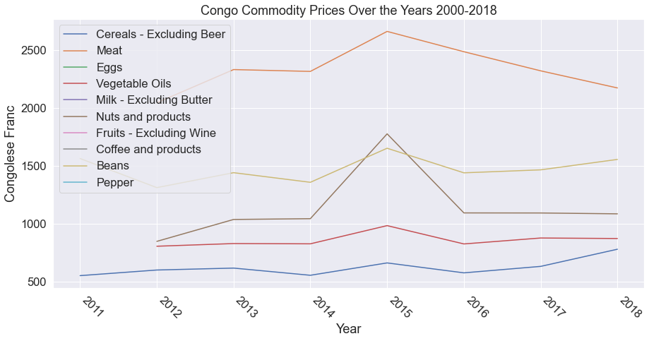

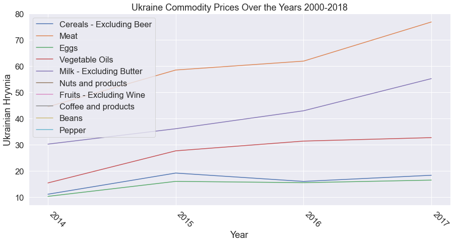

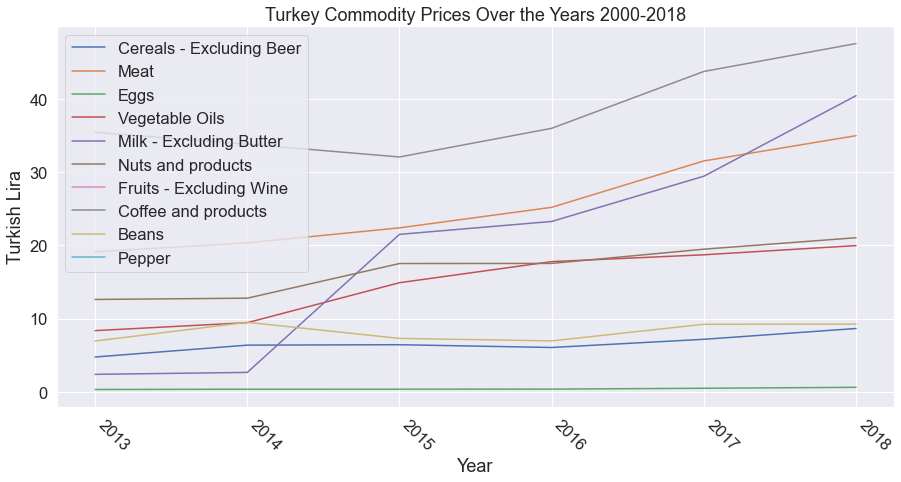

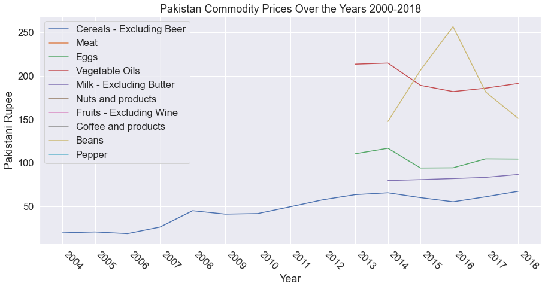

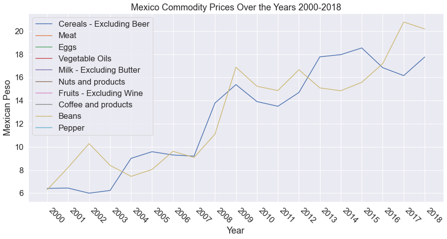

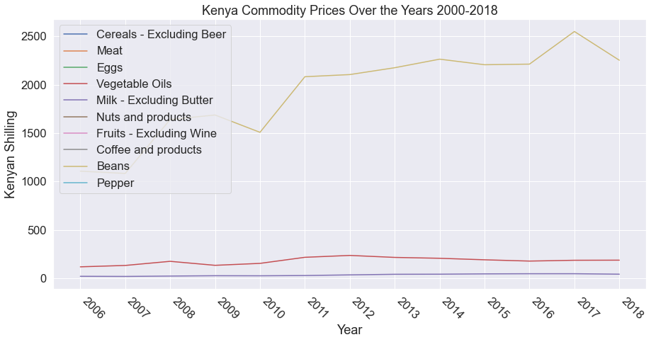

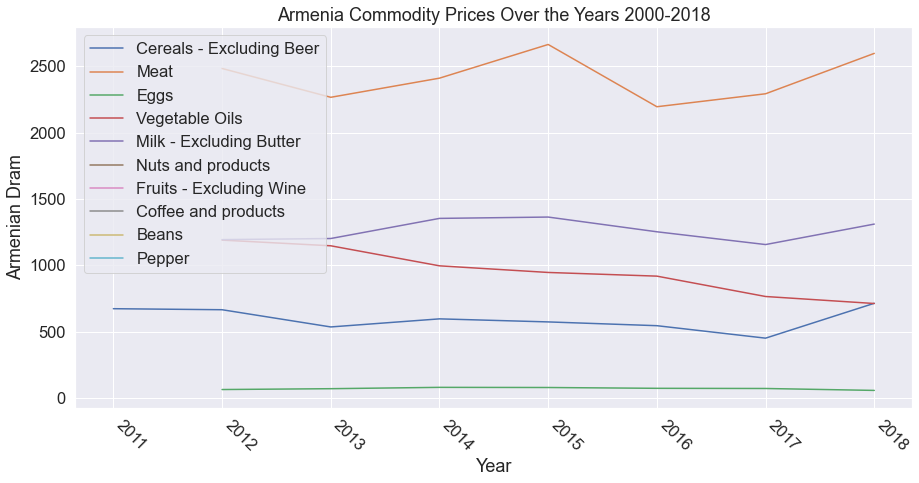

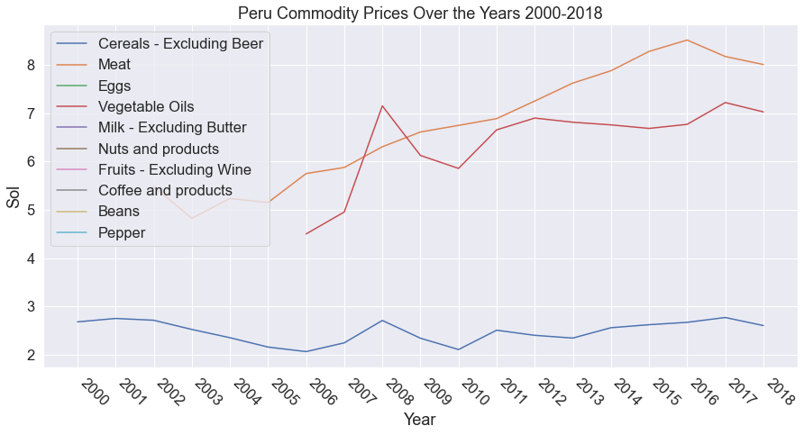

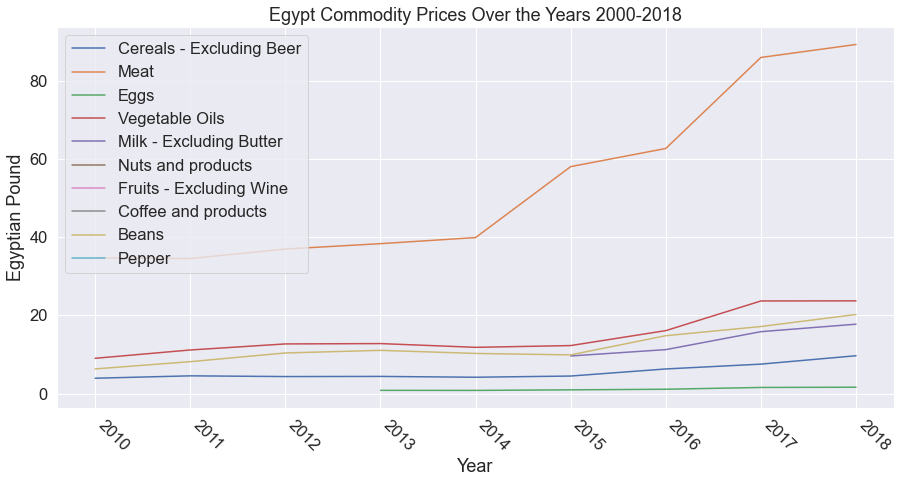

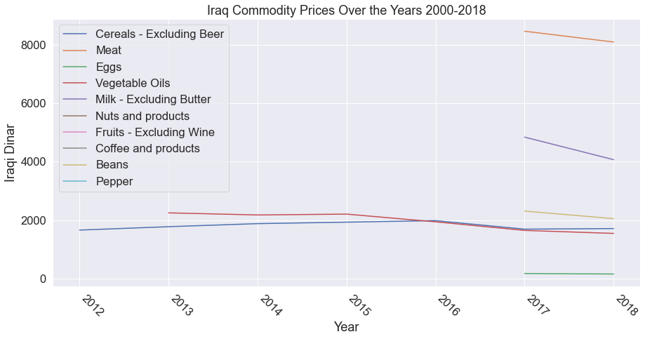

```python
# list of countries, foods of interest, and currencies
countries = ['Congo', 'Ukraine', 'Turkey', 'Pakistan', 'Mexico', 'Kenya', 'Armenia', 'Peru', \
            'Egypt', 'Iraq']
foods = ['Cereals - Excluding Beer', 'Meat', 'Eggs', 'Vegetable Oils', 'Milk - Excluding Butter', 'Nuts and products', 'Fruits - Excluding Wine', \
        'Coffee and products', 'Beans', 'Pepper']
currency_dict = {"Congo": "Congolese Franc", "Ukraine": "Ukrainian Hryvnia", "Turkey": "Turkish Lira",
                 "Pakistan": "Pakistani Rupee", "Mexico": "Mexican Peso", "Kenya": "Kenyan Shilling",
                 "Armenia": "Armenian Dram", "Peru": "Sol", "Egypt": "Egyptian Pound", "Iraq": "Iraqi Dinar"}

# for each country graph their respective food items
for country in countries:
    plt.figure()
    plt.xticks(rotation = -45, horizontalalignment='left')
    plt.title(country + " Commodity Prices Over the Years 2000-2018")
    plt.ylabel(currency_dict[country])
    plt.xlabel("Year")
    # for each food item find price for that year
    for item in foods:
        item_price = []
        # find available years for that country
        years = food_prices_df.loc[(food_prices_df['country'] == country) , 'year'].unique()
        for year in years:
            item_price.append(food_prices_df.loc[(food_prices_df['country'] == country) & (food_prices_df['year'] == year) & (food_prices_df['commodity_mapping'] == item), 'price'].mean())
        sns.lineplot(x=years, y=item_price)
    plt.legend(foods, loc='upper left')
    name_index += 1
```

From these outputs on a country basis, we see that there are much more **smoother changes between years**. While there is some volatility in a given country, overall the changes we see are more consistent than if we examined food prices on a global scale. Not all countries have the same items available, but from what is present we can see that looking from a country by country basis to understand price changes would be a better perspective. We will to use country data (inflation, gdp, supply, etc) to help us make better predictions.

Rather than combining global data for predictions, we will look closer at a country's economic and supply chain data for better analysis. This motivates us to look into more narrow factors such as a country's GDP, unemployment rate, number of refugees, and etc. **Developing these factors with our predictions models will give us more variables to work with to try to explain pricing for a given country.**

We can take a look at the correlation of major economic and supply chain factors to food prices by country. It's also important to note other factors that may not be captured in this dataset like current political stability of the country, whether the country was recently in a natural disaster, and other contextual information that may address rises and falls in food prices. But just purely off of economic, supply chain, and additional demographic information, we want to explore their correlations.

We do a general correlation matrix of all the factors available in our dataset.

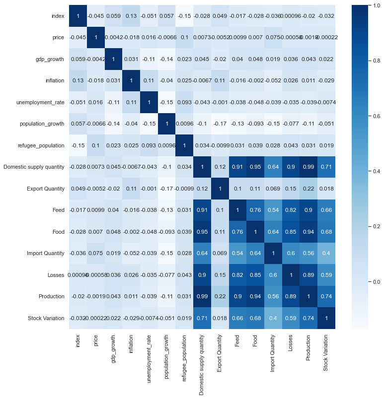

```python
sns.set(rc={"figure.figsize":(12, 12)}, font_scale = 1)

sns.heatmap(food_prices_df.corr(), annot=True, cmap='Blues')
plt.show()
```

From this correlation heat map, we see that the strongest correlations lie with the factors about supply chain. This correlation is to be expected as these factors are often complementary to one another such as *losses* and *production*.

It's also important to note we performed mean imputation during our data cleaning to fill in some values and that sets with global data have issues of coming with inconsistencies. Although we would have liked to see stronger correlations to our factor of price, we still can derive some intuitive relationships and be confident in correlations in our supply chain factors. These caveats in mind will help us develop our prediction model and guide our analysis of the model.

# 4. Hypothesis Testing and Machine Learning

Now we move onto actually forecasting our food prices. We will still use both the individual country data (gdp growth, inflation, etc.) as our exploratory data analysis revealed that prices are very specific to individual countries. In addition, we will also use the supply chain data, even though there isn't a strong correlation with price, in hopes that our machine learning algorithms can fine tune the price prediction using this data (because price for commodities is usually impacted by supply chain factors).

Our process is quite simple. We will first convert all of our data into numerical format to be fed into machine learning algorithms. We will then split up our data into training and testing sets and then choose two machine learning algorithms to use for the forecasting. Then, we will train hyperparameters on the two algorithms, run the algorithms on our training data, and then evaluate the algorithms using both performance metrics and visualizations based on our testing data. In the end, we will choose which algorithm is the best for our food price forecasting use case.

```python
from sklearn import preprocessing

#Dropping columns that are not needed for machine learning
food_prices_df = food_prices_df.drop(["Unit", "index"], axis=1)

#Encoding columns that contain strings into numeric types (labels) so the dataframe can be
#used with machine learning algorithms
string_columns = ["country", "commodity", "currency", "market_type", "unit_of_measurement", "commodity_base",
                  "commodity_mapping"]

label_encoder_dict = {}

for col in string_columns:
    food_prices_df[col] = food_prices_df[col].astype(str)
    label_encoder = preprocessing.LabelEncoder()
    label_encoder.fit(food_prices_df[col])
    food_prices_df[col] = label_encoder.transform(food_prices_df[col])
    label_encoder_dict[col] = label_encoder

food_prices_df
```

|  | country | commodity | currency | market_type | unit_of_measurement | year | price | gdp_growth | inflation | unemployment_rate | ... | commodity_base | commodity_mapping | Domestic supply quantity | Export Quantity | Feed | Food | Import Quantity | Losses | Production | Stock Variation |
| --- | --- | --- | --- | --- | --- | --- | --- | --- | --- | --- | --- | --- | --- | --- | --- | --- | --- | --- | --- | --- | --- |
| 0 | 0 | 64 | 0 | 2 | 69 | 2000 | 1.721375e+01 | 3.636375 | 6.070969 | 11.65 | ... | 8 | 46 | 2898.0 | 0.583333 | 556.250000 | 2600.0 | 929.0 | 147.000000 | 1469.0 | 500.000000 |
| 1 | 0 | 467 | 0 | 2 | 69 | 2000 | 1.211646e+01 | 3.636375 | 6.070969 | 11.65 | ... | 93 | 46 | 2898.0 | 0.583333 | 556.250000 | 2600.0 | 929.0 | 147.000000 | 1469.0 | 500.000000 |
| 2 | 0 | 477 | 0 | 2 | 69 | 2000 | 1.420292e+01 | 3.636375 | 6.070969 | 11.65 | ... | 94 | 46 | 2898.0 | 0.583333 | 556.250000 | 2600.0 | 929.0 | 147.000000 | 1469.0 | 500.000000 |
| 3 | 0 | 200 | 0 | 2 | 78 | 2000 | 1.060087e+06 | 3.636375 | 6.070969 | 11.65 | ... | 49 | 19 | 319.0 | 0.583333 | 556.250000 | 319.0 | 0.0 | 596.115942 | 319.0 | -84.101449 |
| 4 | 0 | 64 | 0 | 2 | 69 | 2001 | 1.652267e+01 | 3.636375 | 6.070969 | 11.63 | ... | 8 | 46 | 2976.0 | 0.583333 | 556.250000 | 2668.0 | 1229.0 | 160.000000 | 1597.0 | 150.000000 |
| ... | ... | ... | ... | ... | ... | ... | ... | ... | ... | ... | ... | ... | ... | ... | ... | ... | ... | ... | ... | ... | ... |
| 10687 | 80 | 290 | 60 | 2 | 70 | 2018 | 2.167952e+00 | 2.047700 | 61.310986 | 5.07 | ... | 57 | 44 | 199.0 | 1.000000 | 18.814815 | 160.0 | 140.0 | 49.169811 | 92.0 | 32.000000 |
| 10688 | 80 | 415 | 60 | 2 | 69 | 2018 | 1.000000e+00 | 2.047700 | 61.310986 | 5.07 | ... | 77 | 34 | 103.0 | 5.000000 | 2.000000 | 68.0 | 8.0 | 3.000000 | 100.0 | 0.000000 |
| 10689 | 80 | 426 | 60 | 2 | 69 | 2018 | 4.152941e-01 | 2.047700 | 61.310986 | 5.07 | ... | 77 | 34 | 103.0 | 5.000000 | 2.000000 | 68.0 | 8.0 | 3.000000 | 100.0 | 0.000000 |
| 10690 | 80 | 444 | 60 | 2 | 69 | 2018 | 1.291429e+00 | 2.047700 | 61.310986 | 5.07 | ... | 83 | 38 | 350.0 | 85.000000 | 18.814815 | 299.0 | 0.0 | 49.169811 | 435.0 | 0.000000 |
| 10691 | 80 | 471 | 60 | 2 | 69 | 2018 | 1.322667e+00 | 2.047700 | 61.310986 | 5.07 | ... | 94 | 46 | 301.0 | 3.000000 | 18.814815 | 298.0 | 310.0 | 1.000000 | 45.0 | 50.000000 |

10692 rows × 22 columns

In the previous code block, we are preparing the dataset to be fed into machine learning algorithms. This consists of deleting columns that we don't believe matter to the machine learning algorithm and encoding categorical variables into numerical variables.

Finally, we encoded all of the columns with string data types into numerical variables. Our first idea was to use one hot encoding and create dummy variables for the strings in this process, but we realized that with the the number of unique strings within each column, we would end up with too many columns, which could lower the performance of our machine learning algorithms. Thus, we resorted to using label encodings, in which each string is given a unique number for identification purposes.

```python
from sklearn.model_selection import train_test_split

#Creating training and testing datasets for holdout validation
features_lst = list(food_prices_df.columns)
features_lst.remove("price")

features = food_prices_df[features_lst]
target_var = food_prices_df["price"]

X_train, X_test, y_train, y_test = train_test_split(features, target_var, test_size = 0.4, random_state = 42)
```

In the previous code block, we split up our dataframe into training and testing datasets. We withhold 40% of the data for testing purposes, higher than the recommended 30%, because given the complexity of our dataset we would observe more accurate performance metrics if we tested it on a higher percentage of the data. We have a substantial amount of datapoints, 10692, so withholding more data for testing purposes wouldn't jeopardize our training process.

In addition, we also set the random state of the function to 42, in order to repreoduce the same results as we run the notebook multiple times.

```python
from sklearn.ensemble import RandomForestRegressor
from sklearn.tree import DecisionTreeRegressor

#Hyperparameter Tuning for Random Forest
n_estimators_lst = [150, 200, 500]
max_features_lst = [None, "auto", "sqrt", "log2"]
bootstrap_lst = [True, False]

accuracy = -1
n_estimators_final = -1
max_features_final = -1
bootstrap_final = -1

#Determining best parameter for n_estimators
for n_estimators_val in n_estimators_lst:
    random_forest_model = RandomForestRegressor(n_estimators=n_estimators_val,
                                                random_state=42)
    random_forest_model.fit(X_train, y_train)
    temp_accuracy = random_forest_model.score(X_test, y_test)

    if temp_accuracy > accuracy:
        accuracy = temp_accuracy
        n_estimators_final = n_estimators_val

accuracy = -1

#Determining best parameter for max_features
for max_features_val in max_features_lst:
    random_forest_model = RandomForestRegressor(n_estimators=n_estimators_final,
                                                max_features=max_features_val,
                                                random_state=42)
    random_forest_model.fit(X_train, y_train)
    temp_accuracy = random_forest_model.score(X_test, y_test)

    if temp_accuracy > accuracy:
        accuracy = temp_accuracy
        max_features_final = max_features_val

accuracy = -1

#Determining best parameter for bootstrap
for bootstrap_val in bootstrap_lst:
    random_forest_model = RandomForestRegressor(n_estimators=n_estimators_final,
                                                bootstrap=bootstrap_val,
                                                random_state=42)
    random_forest_model.fit(X_train, y_train)
    temp_accuracy = random_forest_model.score(X_test, y_test)

    if temp_accuracy > accuracy:
        accuracy = temp_accuracy
        bootstrap_final = bootstrap_val

#Printing out best hyperparameters
print("Best Hyperparamaters for Random Forest Regressor:")
print("*********************")
print("n_estimators:", n_estimators_final)
print("max_features:", max_features_final)
print("bootstrap:", bootstrap_final)
```

```
Best Hyperparamaters for Random Forest Regressor:
n_estimators: 500
max_features: sqrt
bootstrap: True
```

We had many algorithms to choose from when deciding which two algorithms to use. We knew we had to pick a regression, as we were predicting food prices, so we first thought about using linear regression. We quickly realized that it would be impossible to have a linear regressor match every single relationship within our database and dropped the idea. We then moved on to k nearest neighbors regression, but also realized that this was unrealistic – we had no idea if our data clustered or what the value of k would even be.

That’s when we realized that random forests and decision trees would probably be the best to use. Both algorithms are able to take complex data and derive meaningful relationships out of them, at the expense of some interpretability. Thus, we conduct hyperparameter testing for these two algorithms, with this code block being designated for random forest hyperparameters.

Specifically, in this code block, we decided to use the default hyperparameters for everything except for n_estimators (because our data is quite large so we thought that we would need more trees in the forest than the default 100 trees), max_features, and bootstrap.

Our methodology is simple. For each parameter, we loop through the candidate parameter values, creating a model and testing its accuracy. We then choose the parameter value with the highest accuracy. We then move on to the next parameter, utilizing the optimized parameter that we determined previously in the next model we create. In the end, we print out the best hyperparameters based on the highest accuracy.

```python
#Hyperparameter Tuning for Decision Trees
criterion_lst = ["squared_error", "absolute_error"]
splitter_lst = ["best", "random"]
max_features_lst = [None, "auto", "sqrt", "log2"]

accuracy = -1
criterion_final = -1
splitter_final = -1
max_features_final = -1

#Determining best parameter for criterion
for criterion_val in criterion_lst:
    decision_tree_model = DecisionTreeRegressor(criterion=criterion_val,
                                                random_state=42)
    decision_tree_model.fit(X_train, y_train)
    temp_accuracy = decision_tree_model.score(X_test, y_test)

    if temp_accuracy > accuracy:
        accuracy = temp_accuracy
        criterion_final = criterion_val

accuracy = -1

#Determining best parameter for splitter
for splitter_val in splitter_lst:
    decision_tree_model = DecisionTreeRegressor(criterion=criterion_final,
                                                splitter=splitter_val,
                                                random_state=42)
    decision_tree_model.fit(X_train, y_train)
    temp_accuracy = decision_tree_model.score(X_test, y_test)

    if temp_accuracy > accuracy:
        accuracy = temp_accuracy
        splitter_final = splitter_val


accuracy = -1

#Determining best parameter for max_features
for max_features_val in max_features_lst:
    decision_tree_model = DecisionTreeRegressor(criterion=criterion_final,
                                                splitter=splitter_final,
                                                max_features=max_features_val,
                                                random_state=42)
    decision_tree_model.fit(X_train, y_train)
    temp_accuracy = decision_tree_model.score(X_test, y_test)

    if temp_accuracy > accuracy:
        accuracy = temp_accuracy
        max_features_final = max_features_val

#Printing out best hyperparameters
print("Best Hyperparamaters for Decision Tree Regressor:")
print("*********************")
print("criterion:", criterion_final)
print("splitter:", splitter_final)
print("max_features:", max_features_final)
```

```
Best Hyperparamaters for Decision Tree Regressor:
criterion: absolute_error
splitter: best
max_features: None
```

In the above code block, we conduct hyperparameter tuning again, except this time it is for our Decision Tree Regressor. We test criterion, splitter, and max_features hyperparameters for Decision Trees, as these hyperparameters have to do with the splittling occurring within the Decision Trees, which is highly dependent on our data. Thus, it would be unwise to use the default values for these hyperparameters.

```python
from sklearn.metrics import explained_variance_score
from sklearn.metrics import mean_squared_error
from sklearn.metrics import mean_absolute_error
from sklearn.metrics import r2_score

#Create random forest model using hyperparameters, run them on training data,
#and evaluate via performance metrics
random_forest_model = RandomForestRegressor(n_estimators=500,
                                            max_features="sqrt",
                                            bootstrap=True,
                                            random_state=42)

random_forest_model.fit(X_train, y_train)

#Calculating accuracy
accuracy_rf = random_forest_model.score(X_test, y_test)

#Calculating explained variance score and r2 score
y_prediction_rf = random_forest_model.predict(X_test)

explained_var_score_rf = explained_variance_score(y_test, y_prediction_rf)
r2_score_val_rf = r2_score(y_test, y_prediction_rf)

#Printing out metrics
print("Performance Metrics for Random Forest Regressor:")
print("*********************")
print("Accuracy:", accuracy_rf)
print("Explained Variance Score:", explained_var_score_rf)
print("r2 Score:", r2_score_val_rf)

#Create decision tree model using hyperparameters, run them on training data,
#and evaluate via performance metrics
decision_tree_model = DecisionTreeRegressor(criterion="absolute_error",
                                            splitter="best",
                                            max_features=None,
                                            random_state=42)


decision_tree_model.fit(X_train, y_train)

#Calculating accuracy
accuracy_dt = decision_tree_model.score(X_test, y_test)

#Calculating explained variance score and r2 score
y_prediction_dt = decision_tree_model.predict(X_test)

explained_var_score_dt = explained_variance_score(y_test, y_prediction_dt)
r2_score_val_dt = r2_score(y_test, y_prediction_dt)

#Printing out metrics
print("Performance Metrics for Decision Tree Regressor:")
print("*********************")
print("Accuracy:", accuracy_dt)
print("Explained Variance Score:", explained_var_score_dt)
print("r2 Score:", r2_score_val_dt)
```

```
Performance Metrics for Random Forest Regressor:
Accuracy: 0.7255664865314437
Explained Variance Score: 0.7256214707756846
r2 Score: 0.7255664865314437
Performance Metrics for Decision Tree Regressor:
Accuracy: 0.8448413663815266
Explained Variance Score: 0.8449020541031171
r2 Score: 0.8448413663815266
```

Next, we use the hyperparameters we determined previously in our random forest and decision tree algorithms. We run the algorithms on our training data and evaluate it on our testing data using three metrics: accuracy, explained variance score, and r2 score. We can see that the decision tree regressor performed much better, by 12%, than the random forest regressor. The explained variance score and r2 score is also higher for decision trees by the same amount.

```python
import matplotlib.pyplot as plt
import seaborn as sns

#Revert numerical encoded values back to their respective categorical values
undo_encoder_cols = ["country", "commodity_base", "commodity_mapping"]

for col in undo_encoder_cols:
    col_lable_encoder = label_encoder_dict[col]
    X_test[col] = col_lable_encoder.inverse_transform(X_test[col])

X_test
```

|  | country | commodity | currency | market_type | unit_of_measurement | year | gdp_growth | inflation | unemployment_rate | population_growth | ... | commodity_base | commodity_mapping | Domestic supply quantity | Export Quantity | Feed | Food | Import Quantity | Losses | Production | Stock Variation |
| --- | --- | --- | --- | --- | --- | --- | --- | --- | --- | --- | --- | --- | --- | --- | --- | --- | --- | --- | --- | --- | --- |
| 1964 | Colombia | 302 | 8 | 3 | 69 | 2017 | -0.163409 | 5.133736 | 8.870000 | 1.513747 | ... | Onions | Onions | 855.00 | 1.000000 | 1716.471592 | 696.00 | 40.00 | 159.000000 | 815.00 | 15.622951 |
| 5267 | Kyrgyzstan | 459 | 26 | 2 | 69 | 2018 | 2.637649 | 6.569280 | 6.237581 | 1.988336 | ... | Tomatoes | Tomatoes and products | 232.00 | 1.000000 | 335.224483 | 220.00 | 8.00 | 2.000000 | 225.00 | 1.369478 |
| 9630 | Tajikistan | 336 | 55 | 2 | 69 | 2018 | 4.992101 | 2.492227 | 6.720000 | 2.453552 | ... | Potatoes | Potatoes and products | 995.00 | 0.000000 | 566.000000 | 312.00 | 31.00 | 71.000000 | 965.00 | 1.005025 |
| 5503 | Lebanon | 154 | 30 | 2 | 20 | 2016 | -1.216531 | 0.989908 | 6.260000 | 2.741932 | ... | Fish | Fish, Seafood | 64.11 | 0.580000 | 4.540000 | 59.57 | 59.38 | 26.083333 | 5.32 | -32.298246 |
| 1683 | Colombia | 205 | 8 | 3 | 69 | 2009 | 0.020713 | 4.064225 | 12.070000 | 1.112492 | ... | Maize | Maize and products | 5007.00 | 36.000000 | 3538.000000 | 1372.00 | 3253.00 | 76.000000 | 1560.00 | 230.000000 |
| ... | ... | ... | ... | ... | ... | ... | ... | ... | ... | ... | ... | ... | ... | ... | ... | ... | ... | ... | ... | ... | ... |
| 26 | Afghanistan | 477 | 0 | 2 | 69 | 2007 | 11.022787 | 22.527756 | 11.180000 | 2.493830 | ... | Wheat flour | Wheat and products | 5140.00 | 0.583333 | 556.250000 | 4164.00 | 1056.00 | 673.000000 | 4484.00 | -400.000000 |
| 6114 | Mexico | 399 | 39 | 3 | 69 | 2012 | 2.247140 | 4.065927 | 4.890000 | 1.355294 | ... | Rice | Cereals - Excluding Beer | 49584.00 | 2337.000000 | 21317.000000 | 19129.00 | 17866.00 | 3782.000000 | 33555.00 | 500.000000 |
| 3918 | Guinea | 445 | 17 | 2 | 69 | 2017 | 7.292112 | 10.356507 | 4.260000 | 2.764880 | ... | Sugar | Sugar (Raw Equivalent) | 146.00 | 0.000000 | 728.636364 | 146.00 | 130.00 | 346.409091 | 25.00 | 9.000000 |
| 9596 | Tajikistan | 209 | 55 | 2 | 69 | 2017 | 4.486563 | 9.805466 | 6.810000 | 2.470451 | ... | Maize | Maize and products | 228.00 | 8.665653 | 140.000000 | 75.00 | 2.00 | 10.000000 | 218.00 | -8.000000 |
| 4629 | Jordan | 190 | 23 | 2 | 69 | 2014 | -1.250621 | 3.445324 | 11.900000 | 4.586585 | ... | Lentils | Pulses | 74.00 | 1.000000 | 8.000000 | 62.00 | 62.00 | 1.000000 | 12.00 | 0.000000 |

4277 rows × 21 columns

In this code block, we revert the categorical values that we previous encoded into numerical values back into their respective string values. We do this because we're going to be doing some analysis and plotting of countries, food commodities, etc. in the next few steps and we need to see the string values to derive meaningful insights.

```python
#Create separate dataframes for y_test, y_prediction for random forest, and y_prediction for decision tree
#and join them together based on y_test's indices
y_test_df = pd.DataFrame(y_test)

y_prediction_rf_df = pd.DataFrame(y_prediction_rf)
y_prediction_rf_df = y_prediction_rf_df.set_index(y_test.index)

y_prediction_dt_df = pd.DataFrame(y_prediction_dt)
y_prediction_dt_df = y_prediction_dt_df.set_index(y_test.index)

test_prediction_df = y_test_df.join(y_prediction_rf_df)
test_prediction_df = test_prediction_df.rename({"price": "y_test", 0: "y_prediction_rf"}, axis=1)

test_prediction_df = test_prediction_df.join(y_prediction_dt_df)
test_prediction_df = test_prediction_df.rename({0: "y_prediction_dt"}, axis=1)

#Join the y_prediction and y_test values to the X_test dataframe, and then create residual
#columns for the random forest and decision tree algorithms via their prediction values
test_prediction_df = X_test.join(test_prediction_df)
test_prediction_df["residual_rf"] = test_prediction_df["y_test"] - test_prediction_df["y_prediction_rf"]
test_prediction_df["residual_dt"] = test_prediction_df["y_test"] - test_prediction_df["y_prediction_dt"]
test_prediction_df
```

|  | country | commodity | currency | market_type | unit_of_measurement | year | gdp_growth | inflation | unemployment_rate | population_growth | ... | Food | Import Quantity | Losses | Production | Stock Variation | y_test | y_prediction_rf | y_prediction_dt | residual_rf | residual_dt |
| --- | --- | --- | --- | --- | --- | --- | --- | --- | --- | --- | --- | --- | --- | --- | --- | --- | --- | --- | --- | --- | --- |
| 1964 | Colombia | 302 | 8 | 3 | 69 | 2017 | -0.163409 | 5.133736 | 8.870000 | 1.513747 | ... | 696.00 | 40.00 | 159.000000 | 815.00 | 15.622951 | 1990.000000 | 2301.802523 | 2012.030303 | -311.802523 | -22.030303 |
| 5267 | Kyrgyzstan | 459 | 26 | 2 | 69 | 2018 | 2.637649 | 6.569280 | 6.237581 | 1.988336 | ... | 220.00 | 8.00 | 2.000000 | 225.00 | 1.369478 | 86.365481 | 133.922467 | 95.556380 | -47.556987 | -9.190900 |
| 9630 | Tajikistan | 336 | 55 | 2 | 69 | 2018 | 4.992101 | 2.492227 | 6.720000 | 2.453552 | ... | 312.00 | 31.00 | 71.000000 | 965.00 | 1.005025 | 2.802315 | 20.278495 | 3.160583 | -17.476179 | -0.358268 |
| 5503 | Lebanon | 154 | 30 | 2 | 20 | 2016 | -1.216531 | 0.989908 | 6.260000 | 2.741932 | ... | 59.57 | 59.38 | 26.083333 | 5.32 | -32.298246 | 1004.346195 | 1983.331118 | 1091.759809 | -978.984923 | -87.413614 |
| 1683 | Colombia | 205 | 8 | 3 | 69 | 2009 | 0.020713 | 4.064225 | 12.070000 | 1.112492 | ... | 1372.00 | 3253.00 | 76.000000 | 1560.00 | 230.000000 | 908.525000 | 1661.953456 | 943.083333 | -753.428456 | -34.558333 |
| ... | ... | ... | ... | ... | ... | ... | ... | ... | ... | ... | ... | ... | ... | ... | ... | ... | ... | ... | ... | ... | ... |
| 26 | Afghanistan | 477 | 0 | 2 | 69 | 2007 | 11.022787 | 22.527756 | 11.180000 | 2.493830 | ... | 4164.00 | 1056.00 | 673.000000 | 4484.00 | -400.000000 | 15.254167 | 56.792145 | 14.163318 | -41.537978 | 1.090849 |
| 6114 | Mexico | 399 | 39 | 3 | 69 | 2012 | 2.247140 | 4.065927 | 4.890000 | 1.355294 | ... | 19129.00 | 17866.00 | 3782.000000 | 33555.00 | 500.000000 | 18.996250 | 38.689863 | 16.926250 | -19.693613 | 2.070000 |
| 3918 | Guinea | 445 | 17 | 2 | 69 | 2017 | 7.292112 | 10.356507 | 4.260000 | 2.764880 | ... | 146.00 | 130.00 | 346.409091 | 25.00 | 9.000000 | 8989.959350 | 9009.631622 | 8112.500000 | -19.672272 | 877.459350 |
| 9596 | Tajikistan | 209 | 55 | 2 | 69 | 2017 | 4.486563 | 9.805466 | 6.810000 | 2.470451 | ... | 75.00 | 2.00 | 10.000000 | 218.00 | -8.000000 | 2.797208 | 163.640204 | 3.116302 | -160.842996 | -0.319094 |
| 4629 | Jordan | 190 | 23 | 2 | 69 | 2014 | -1.250621 | 3.445324 | 11.900000 | 4.586585 | ... | 62.00 | 62.00 | 1.000000 | 12.00 | 0.000000 | 1.188583 | 73.363444 | 1.189000 | -72.174860 | -0.000417 |

4277 rows × 26 columns

In the above code block, we created a dataframe of our original prices (y_test), prediction prices from random forest (y_prediction_rf), and prediction prices from decision trees (y_prediction_dt), in order to join them into our X_test dataframe. We then calculated residuals for each of the random forest and decision tree algorithms and stored them in the X_test dataframe. This was all done so that we could analyze and plot the residuals based on different features (country, commodity, etc) in the next steps.

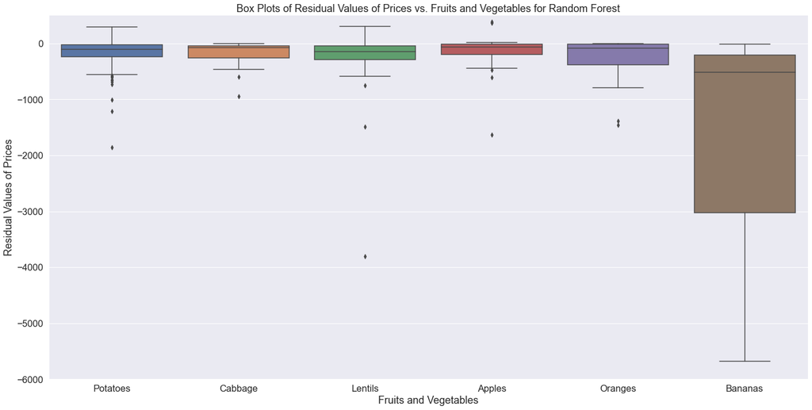

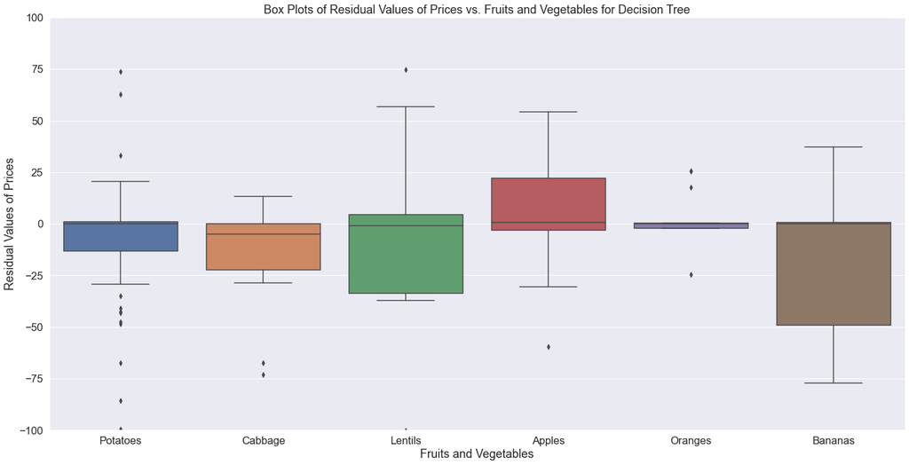

```python
#Plotting residuals against major food groups within fruits and vegetables for Random Forest Regressor
fv_groups = ["Bananas", "Oranges", "Apples", "Potatoes", "Lentils", "Cabbage"]
fv_groups_df = test_prediction_df[test_prediction_df["commodity_base"].isin(fv_groups)]

sns.set(rc={"figure.figsize":(20, 10)}, font_scale = 1.5)

#Plotting residuals against major food groups within fruits and vegetables for Decision Tree Regressor
cat_plot_fv_groups_rf = sns.catplot(x="commodity_base", y="residual_rf", data=fv_groups_df, kind="box",
                                    height=10.0, aspect=20.0/10.0)
cat_plot_fv_groups_rf.set(ylim=(-6000, 500))
cat_plot_fv_groups_rf.set_xlabels("Fruits and Vegetables")
cat_plot_fv_groups_rf.set_ylabels("Residual Values of Prices")
cat_plot_fv_groups_rf.set(title="Box Plots of Residual Values of Prices vs. Fruits and Vegetables for Random Forest")

plt.show()

#Plotting residuals against major food groups within fruits and vegetables for Decision Tree Regressor
cat_plot_fv_groups_dt = sns.catplot(x="commodity_base", y="residual_dt", data=fv_groups_df, kind="box",
                                    height=10.0, aspect=20.0/10.0)
cat_plot_fv_groups_dt.set(ylim=(-100, 100))
cat_plot_fv_groups_dt.set_xlabels("Fruits and Vegetables")
cat_plot_fv_groups_dt.set_ylabels("Residual Values of Prices")
cat_plot_fv_groups_dt.set(title="Box Plots of Residual Values of Prices vs. Fruits and Vegetables for Decision Tree")
```

In the above code block, we created box plots of residuals for major fruit and vegetables for our random forest and decision tree algorithms. To narrow in on the key points of the plots, we set the y-axis limit to ignore extreme outliers.

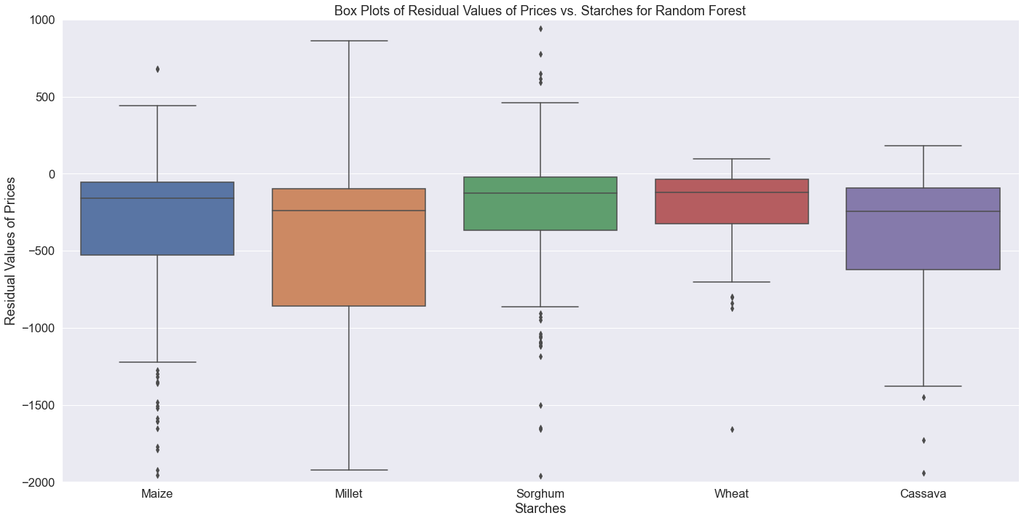

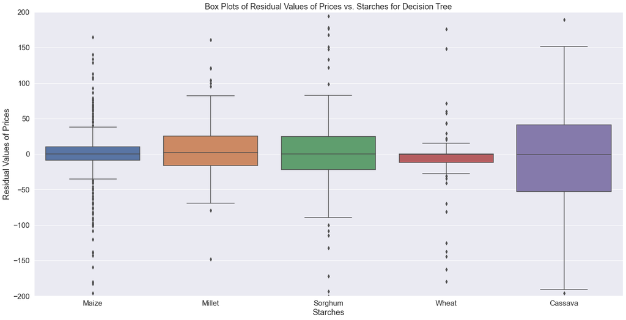

```python
#Plotting residuals against starch groups for Random Forest Regressor
starch_groups = ["Wheat", "Maize", "Sorghum", "Cassava", "Millet"]
starch_groups_df = test_prediction_df[test_prediction_df["commodity_base"].isin(starch_groups)]

cat_plot_starch_groups_rf = sns.catplot(x="commodity_base", y="residual_rf", data=starch_groups_df, kind="box",
                                    height=10.0, aspect=20.0/10.0)
cat_plot_starch_groups_rf.set(ylim=(-2000, 1000))
cat_plot_starch_groups_rf.set_xlabels("Starches")
cat_plot_starch_groups_rf.set_ylabels("Residual Values of Prices")
cat_plot_starch_groups_rf.set(title="Box Plots of Residual Values of Prices vs. Starches for Random Forest")
plt.show()

#Plotting residuals against starch groups for Decision Tree Regressor
cat_plot_starch_groups_dt = sns.catplot(x="commodity_base", y="residual_dt", data=starch_groups_df, kind="box",
                                    height=10.0, aspect=20.0/10.0)
cat_plot_starch_groups_dt.set(ylim=(-200, 200))
cat_plot_starch_groups_dt.set_xlabels("Starches")
cat_plot_starch_groups_dt.set_ylabels("Residual Values of Prices")
cat_plot_starch_groups_dt.set(title="Box Plots of Residual Values of Prices vs. Starches for Decision Tree")
```

In the previous code block, we repeated the same procedure we used to create the box plots for fruits and vegetables for a new food group, starches.

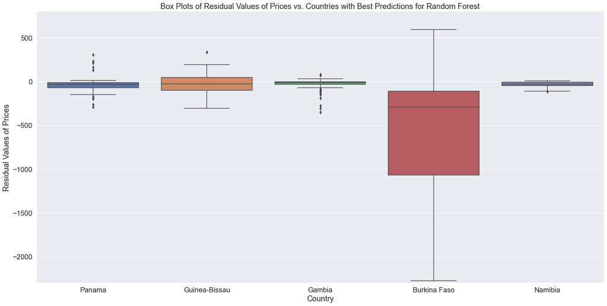

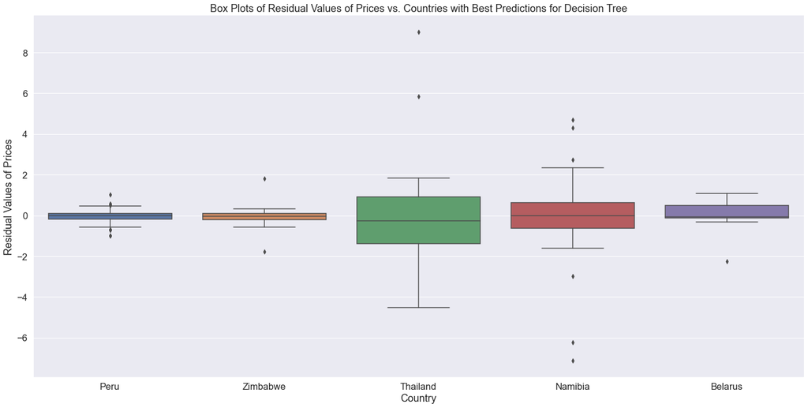

```python
#Plotting residuals against countries with the best price predictions for Random Forest Regressor
mean_country_df = test_prediction_df.groupby(["country"]).mean()
mean_country_df["residual_rf"] = abs(mean_country_df["residual_rf"])
mean_country_df.sort_values(by=["residual_rf"])
countries = list(mean_country_df["residual_rf"].nsmallest(n=5).index)
countries_df = test_prediction_df[test_prediction_df["country"].isin(countries)]

cat_plot_country_top_groups_rf = sns.catplot(x="country", y="residual_rf", data=countries_df, kind="box",
                                    height=10.0, aspect=20.0/10.0)
cat_plot_country_top_groups_rf.set(ylim=(-2300, 800))
cat_plot_country_top_groups_rf.set_xlabels("Country")
cat_plot_country_top_groups_rf.set_ylabels("Residual Values of Prices")
cat_plot_country_top_groups_rf.set(title="Box Plots of Residual Values of Prices vs. Countries with Best Predictions for Random Forest")
plt.show()

#Plotting residuals against countries with the best price predictions for Decision Tree Regressor
mean_country_df = test_prediction_df.groupby(["country"]).mean()
mean_country_df["residual_dt"] = abs(mean_country_df["residual_dt"])
mean_country_df.sort_values(by=["residual_dt"])
countries = list(mean_country_df["residual_dt"].nsmallest(n=5).index)
countries_df = test_prediction_df[test_prediction_df["country"].isin(countries)]

cat_plot_country_top_groups_dt = sns.catplot(x="country", y="residual_dt", data=countries_df, kind="box",
                                    height=10.0, aspect=20.0/10.0)
cat_plot_country_top_groups_dt.set_xlabels("Country")
cat_plot_country_top_groups_dt.set_ylabels("Residual Values of Prices")
cat_plot_country_top_groups_dt.set(title="Box Plots of Residual Values of Prices vs. Countries with Best Predictions for Decision Tree")
```

Here we plotted the residual values of the countries that had the smallest average residual values for each algorithm (the countries that had the best predictions for its food prices). This was done in the same manner as with the previous box plots. For the random forest and decision tree algorithms, not only are the countries with the smallest average residuals different, but the decision tree algorithm is quite spot on (with residual values of about +/- 2, ignoring outliers), while the random forest algorithm has higher residuals, even for its best predicted countries.

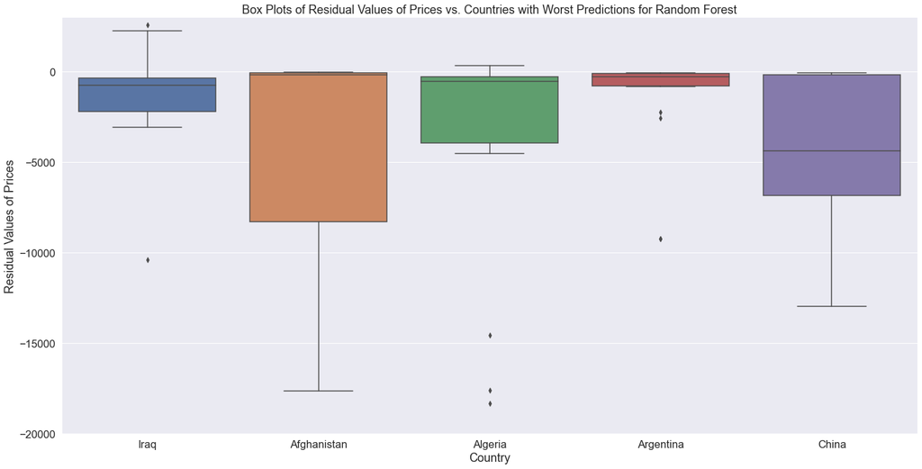

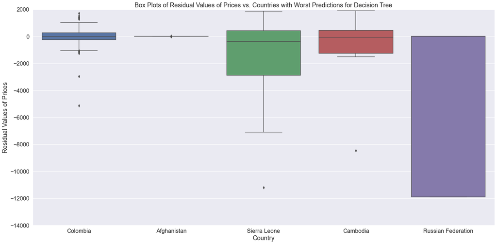

```python
#Plotting residuals against countries with the worst price predictions for Random Forest Regressor
mean_country_df = test_prediction_df.groupby(["country"]).mean()
mean_country_df["residual_rf"] = abs(mean_country_df["residual_rf"])
mean_country_df.sort_values(by=["residual_rf"])
countries = list(mean_country_df["residual_rf"].nlargest(n=5).index)
countries_df = test_prediction_df[test_prediction_df["country"].isin(countries)]

cat_plot_country_bottom_groups_rf = sns.catplot(x="country", y="residual_rf", data=countries_df, kind="box",
                                    height=10.0, aspect=20.0/10.0)
cat_plot_country_bottom_groups_rf.set(ylim=(-20000, 3000))
cat_plot_country_bottom_groups_rf.set_xlabels("Country")
cat_plot_country_bottom_groups_rf.set_ylabels("Residual Values of Prices")
cat_plot_country_bottom_groups_rf.set(title="Box Plots of Residual Values of Prices vs. Countries with Worst Predictions for Random Forest")
plt.show()

#Plotting residuals against countries with the worst price predictions for Decision Tree Regressor
mean_country_df = test_prediction_df.groupby(["country"]).mean()
mean_country_df["residual_dt"] = abs(mean_country_df["residual_dt"])
mean_country_df.sort_values(by=["residual_dt"])
countries = list(mean_country_df["residual_dt"].nlargest(n=5).index)
countries_df = test_prediction_df[test_prediction_df["country"].isin(countries)]

cat_plot_country_bottom_groups_dt = sns.catplot(x="country", y="residual_dt", data=countries_df, kind="box",
                                    height=10.0, aspect=20.0/10.0)
cat_plot_country_bottom_groups_dt.set(ylim=(-14000, 2000))
cat_plot_country_bottom_groups_dt.set_xlabels("Country")
cat_plot_country_bottom_groups_dt.set_ylabels("Residual Values of Prices")
cat_plot_country_bottom_groups_dt.set(title="Box Plots of Residual Values of Prices vs. Countries with Worst Predictions for Decision Tree")
```

Here we plotted the residual values of the countries that had the largest average residual values (the countries that had the worst predictions for its food prices) for each algorithm. It's easy to note that the decision tree algorithm was still much closer to the actual value than the random forest algorithm (the residuals for decision tree can fit within the range -14000 to +2000, whilst the range for random forest is -20000 to +3000).

After analyzing the accuracy and the residuals by food groups and countries for both algorithms, we can say that the **decision tree algorithm consistently outperforms the random forest algorithm** and is a much better candidate for forecasting food prices in developing nations.

# 5. Analysis and Conclusion

Our project sought to utilize the relationships between food prices and a country’s economic/supply chain data to develop forecasting models on future food prices. This required a lot of research into finding appropriate datasets and also pulling separate datasets into one working data frame. Each country also had a vast amount of data which we pruned or missing data points that we performed mean imputation to replace. This led to **significant work in the data curation portion** where we had to merge several csv files and perform label mapping to many food items. We discovered a lot of data quality challenges and entity resolution made the start of the project quite difficult. There were also other factors we wanted to include in our dataset such as poverty rate, catastrophic weather events, and more that could affect food prices but comprehensive data on these categories are sparse. We may have been a little too ambitious with tackling this problem and also compiling our own dataset from several sources.

Even with all the proper work done to curate our own dataframe to hold several factors we believed to be relevant to our price prediction model, our exploratory data analysis portion yielded results that were rather inconclusive. We developed a narrative to direct attention to the importance of utilizing a country’s supply chain and economic factors. This was to drive the motivation of including that data for our prediction model. Unfortunately, the correlation of these factors to price was weaker than we liked. There are a few things we could have done differently to possibly yield better results:

- We could have converted prices to a uniform currency but that task would be difficult due to the volatility of exchange rates. We would also have to find another source to correspond with.
- We could have grouped each country by continent and performed separate analysis by each group. It would make sense that countries geographically closer to each other would have stronger economic ties and a more clear relationship to each other. But as the world moved toward globalization, in recent years, geography may become less and less relevant to a country’s economy.
- We could also have grouped by major food groups (meat, plant based proteins, grains, starches, fruits, veggies, etc,) and performed analysis on these groups. For example, it would make sense that grain markets would have higher interactions with one another as these items could have aligned growing seasons, production processing, and other similarities.

Regarding the actual forecasting of the food prices via machine learning, we’d like to conclude by mentioning a few of our thoughts:

Forecasting food prices is a complex task that requires domain knowledge in addition to comprehensive data. However, it is extremely important that suitable models be built for such a task in order to assist with inflation targeting. Our model and process is only rudimentary but, as with all primitive models, it can one day achieve high enough accuracy to be used in production if improved upon.